# BINF 6309 Module 11 Assignment

### Setup

```r
library(maftools)
library(R.utils)
```

# Reading and summarising MAF files

```r
#path to TCGA LAML MAF file
laml.maf = system.file('extdata', 'tcga_laml.maf.gz', package = 'maftools')
#clinical information containing survival information and histology. This is optional
laml.clin = system.file('extdata', 'tcga_laml_annot.tsv', package = 'maftools')

laml = read.maf(maf = laml.maf, clinicalData = laml.clin)
```

```
## -Reading
## -Validating
## -Silent variants: 475
## -Summarizing
## -Processing clinical data
## -Finished in 0.380s elapsed (0.330s cpu)
```

```r
#Typing laml shows basic summary of MAF file.
laml
```

```
## An object of class  MAF
##                    ID          summary  Mean Median
##  1:        NCBI_Build               37    NA     NA
##  2:            Center genome.wustl.edu    NA     NA
##  3:           Samples              193    NA     NA
##  4:            nGenes             1241    NA     NA
##  5:   Frame_Shift_Del               52 0.269      0
##  6:   Frame_Shift_Ins               91 0.472      0
##  7:      In_Frame_Del               10 0.052      0
##  8:      In_Frame_Ins               42 0.218      0
##  9: Missense_Mutation             1342 6.953      7
## 10: Nonsense_Mutation              103 0.534      0
## 11:       Splice_Site               92 0.477      0
## 12:             total             1732 8.974      9
```

```r
#Shows sample summry.
getSampleSummary(laml)
```

| Tumor_Sample_Barcode | Frame_Shift_Del | Frame_Shift_Ins | In_Frame_Del | In_Frame_Ins | Missense_Mutation | Nonsense_Mutation | Splice_Site | total |
| --- | --- | --- | --- | --- | --- | --- | --- | --- |
| TCGA-AB-3009 | 0 | 5 | 0 | 1 | 25 | 2 | 1 | 34 |
| TCGA-AB-2807 | 1 | 0 | 1 | 0 | 16 | 3 | 4 | 25 |
| TCGA-AB-2959 | 0 | 0 | 0 | 0 | 22 | 0 | 1 | 23 |
| TCGA-AB-3002 | 0 | 0 | 0 | 0 | 15 | 1 | 5 | 21 |
| TCGA-AB-2849 | 0 | 1 | 0 | 0 | 16 | 1 | 2 | 20 |
| TCGA-AB-2923 | 1 | 1 | 0 | 0 | 15 | 3 | 0 | 20 |
| TCGA-AB-2972 | 0 | 1 | 0 | 0 | 16 | 2 | 1 | 20 |
| TCGA-AB-2912 | 0 | 1 | 0 | 0 | 15 | 1 | 2 | 19 |
| TCGA-AB-2877 | 0 | 0 | 0 | 1 | 17 | 0 | 0 | 18 |
| TCGA-AB-2927 | 0 | 2 | 0 | 0 | 11 | 2 | 3 | 18 |

[output cut: 183 more lines]

```r
#Shows gene summary.
getGeneSummary(laml)
```

| Hugo_Symbol | Frame_Shift_Del | Frame_Shift_Ins | In_Frame_Del | In_Frame_Ins | Missense_Mutation | Nonsense_Mutation | Splice_Site | total | MutatedSamples | AlteredSamples |
| --- | --- | --- | --- | --- | --- | --- | --- | --- | --- | --- |
| FLT3 | 0 | 0 | 1 | 33 | 15 | 0 | 3 | 52 | 52 | 52 |
| DNMT3A | 4 | 0 | 0 | 0 | 39 | 5 | 6 | 54 | 48 | 48 |
| NPM1 | 0 | 33 | 0 | 0 | 1 | 0 | 0 | 34 | 33 | 33 |
| IDH2 | 0 | 0 | 0 | 0 | 20 | 0 | 0 | 20 | 20 | 20 |
| IDH1 | 0 | 0 | 0 | 0 | 18 | 0 | 0 | 18 | 18 | 18 |
| TET2 | 10 | 4 | 0 | 0 | 4 | 8 | 1 | 27 | 17 | 17 |
| RUNX1 | 1 | 3 | 1 | 0 | 8 | 5 | 1 | 19 | 16 | 16 |
| TP53 | 2 | 2 | 0 | 0 | 11 | 1 | 3 | 19 | 15 | 15 |
| NRAS | 0 | 0 | 0 | 0 | 15 | 0 | 0 | 15 | 15 | 15 |
| CEBPA | 6 | 2 | 2 | 6 | 2 | 1 | 0 | 19 | 13 | 13 |

[output cut: 1231 more lines]

```r
#shows clinical data associated with samples
getClinicalData(laml)
```

| Tumor_Sample_Barcode | FAB_classification | days_to_last_followup | Overall_Survival_Status |
| --- | --- | --- | --- |
| TCGA-AB-2802 | M4 | 365 | 1 |
| TCGA-AB-2803 | M3 | 792 | 1 |
| TCGA-AB-2804 | M3 | 2557 | 0 |
| TCGA-AB-2805 | M0 | 577 | 1 |
| TCGA-AB-2806 | M1 | 945 | 1 |
| TCGA-AB-2807 | M1 | 181 | 1 |
| TCGA-AB-2808 | M2 | 2861 | 0 |
| TCGA-AB-2809 | M3 | 62 | 1 |
| TCGA-AB-2810 | M2 | 31 | 1 |
| TCGA-AB-2812 | M2 | 366 | 1 |

[output cut: 183 more lines]

```r
#Shows all fields in MAF
#getFields(laml)
#Writes maf summary to an output file with basename laml.
write.mafSummary(maf = laml, basename = 'laml')
```

# Visualizing

### plotting MAF summary

number of variants and classifications in barcharts and boxplot.

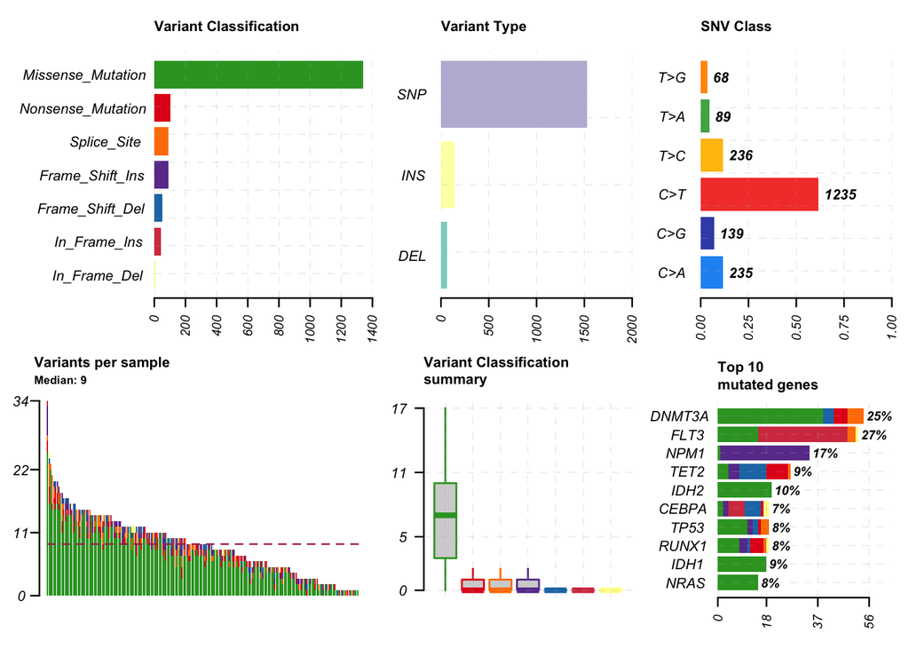

```r
plotmafSummary(maf = laml, rmOutlier = TRUE, addStat = 'median', dashboard = TRUE, titvRaw = FALSE)
```

### Oncoplots

Also known as waterfall plots. Comprehensive view of MAF file in single plot.

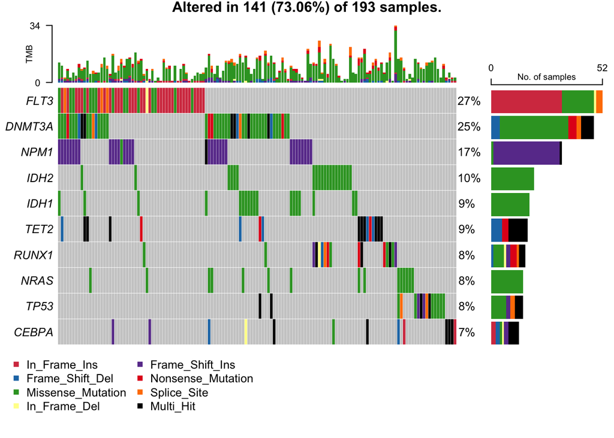

```r
#oncoplot for top ten mutated genes.
oncoplot(maf = laml, top = 10)
```

### Transitions and Transversions

Shows the specific percentage of base changes.

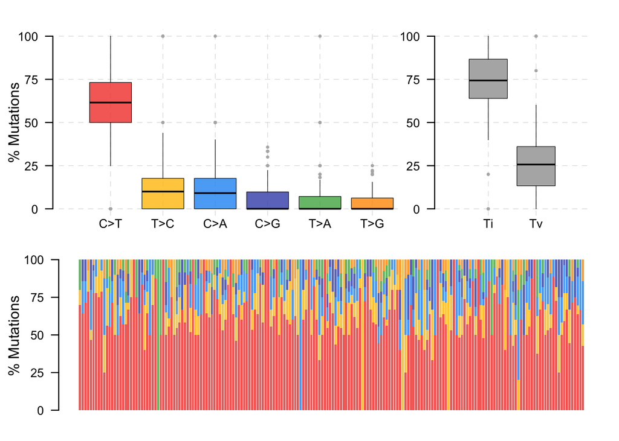

```r
laml.titv = titv(maf = laml, plot = FALSE, useSyn = TRUE)
#plot titv summary
plotTiTv(res = laml.titv)
```

### Lollipop plots for amino acid changes

Requires Amino acid change information, which is not required and thus does not have fixed column name. Default looks for AAChange, here we use Protein_Change. Default plot uses the longest isoform of the gene.

```
## 3 transcripts available. Use arguments refSeqID or proteinID to manually specify tx name.
```

```
##      HGNC refseq.ID protein.ID aa.length
## 1: DNMT3A NM_022552  NP_072046       912
## 2: DNMT3A NM_153759  NP_715640       723
## 3: DNMT3A NM_175629  NP_783328       912
```

```
## Using longer transcript NM_022552 for now.
```

```
## Removed 3 mutations for which AA position was not available
```

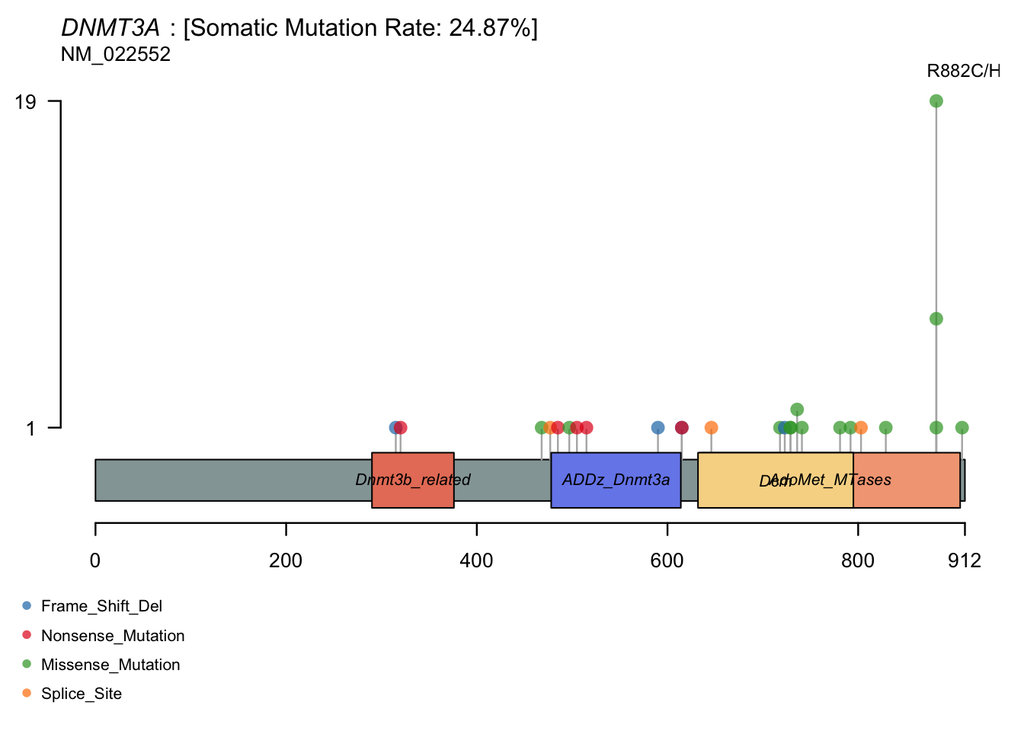

```r
#lollipop plot for DNMT3A, which is one of the most frequent mutated gene in Leukemia.
lollipopPlot(
  maf = laml,
  gene = 'DNMT3A',
  AACol = 'Protein_Change',
  showMutationRate = TRUE,
  labelPos = 882
)
```

Can also plot custom data instead of MAF file - must be 2 column DF with pos and counts. General protein domains can be plotted with plotProtein(gene = , refSeqID = )

### Rainfall plots

Tumors are characterized by genomic loci with localized hyper-mutations (abnormally frequent mutation), which can be viewed by plotting inter variant distance on a linear genomic scale. Kataegis are defined as genomic segments containing six or more consecutive mutations with an average inter-mutation distance of less than 1k bp.

```
## Processing TCGA-A8-A08B..
```

```
## Kataegis detected at:
```

```
##    Chromosome Start_Position End_Position nMuts Avg_intermutation_dist Size
## 1:          8       98129348     98133560     7               702.0000 4212
## 2:          8       98398549     98403536     9               623.3750 4987
## 3:          8       98453076     98456466     9               423.7500 3390
## 4:          8      124090377    124096810    22               306.3333 6433
## 5:         12       97436055     97439705     7               608.3333 3650
## 6:         17       29332072     29336153     8               583.0000 4081
##    Tumor_Sample_Barcode C>G C>T
## 1:         TCGA-A8-A08B   4   3
## 2:         TCGA-A8-A08B   1   8
## 3:         TCGA-A8-A08B   1   8
## 4:         TCGA-A8-A08B   1  21
## 5:         TCGA-A8-A08B   4   3
## 6:         TCGA-A8-A08B   4   4
```

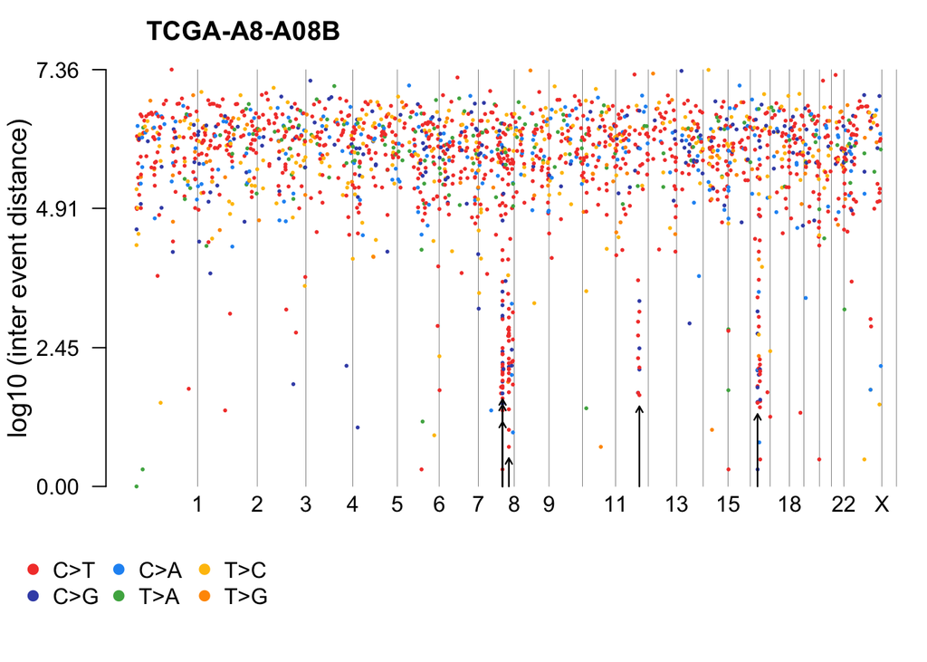

```r
brca <- system.file("extdata", "brca.maf.gz", package = "maftools")
brca = read.maf(maf = brca, verbose = FALSE)
rainfallPlot(maf = brca, detectChangePoints = TRUE, pointSize = 0.4)
```

### Compare mutation load against TCGA cohorts

For visualizing mutation load and burden vs the MC3 public MAF (33 other cohorts). Mutation load- total result from accumulated problematic mutations. Mutation burden- total number of mutations.

```r
laml.mutload = tcgaCompare(maf = laml, cohortName = 'Example-LAML', logscale = TRUE, capture_size = 50)
```

```
## Capture size [TCGA]:  35.8
```

```
## Capture size [Input]: 50
```

```
## Performing pairwise t-test for differences in mutation burden (per MB)..
```

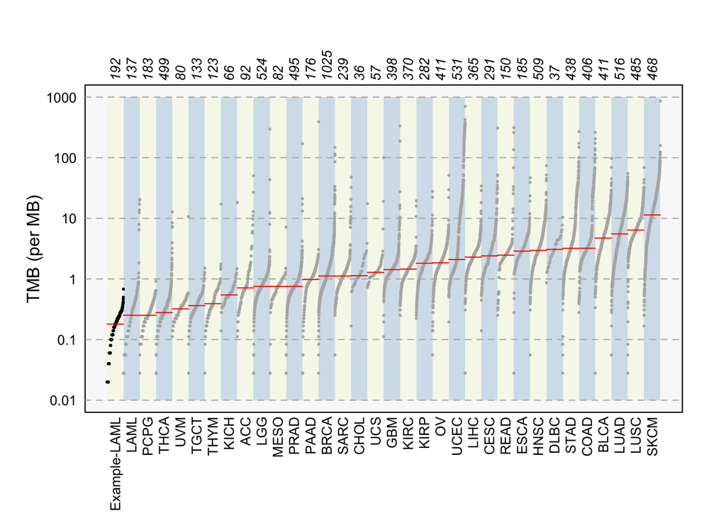

### Plotting VAF

Variant allele frequency as boxplot for estimating clonal status of top mutated genes. Clonal genes would have allele frequency around 50% assuming pure sample.

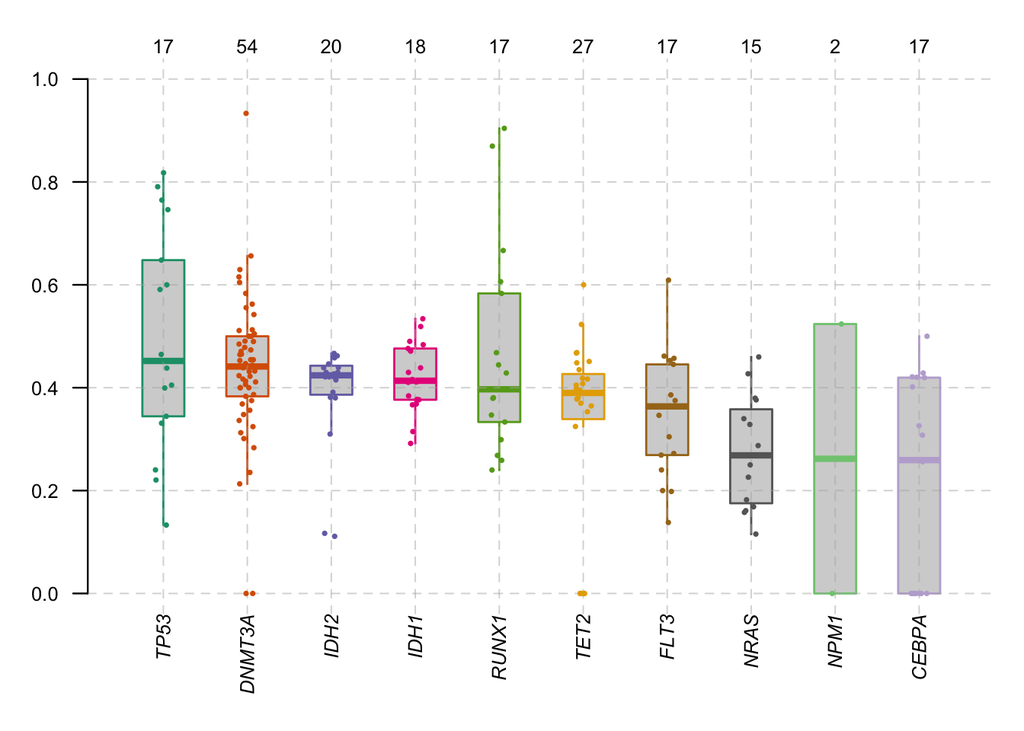

```r
plotVaf(maf = laml, vafCol = 'i_TumorVAF_WU')
```

# Analysis

### Somatic interactions

pair-wise Fisher’s Exact test to detect significant pairs of genes

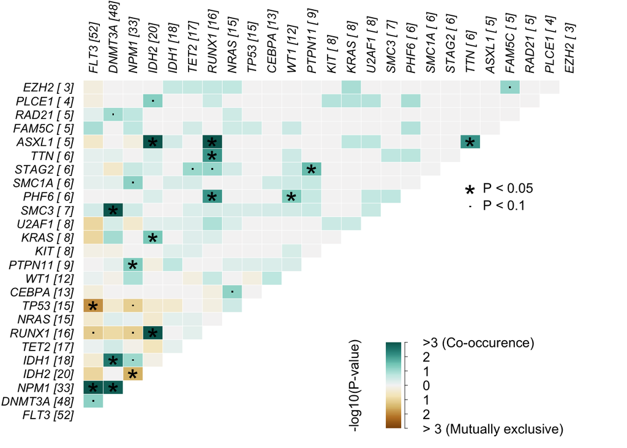

| gene1 | gene2 | pValue | oddsRatio | 00 | 11 | 01 | 10 | pAdj | Event | pair | event_ratio |
| --- | --- | --- | --- | --- | --- | --- | --- | --- | --- | --- | --- |
| ASXL1 | RUNX1 | 0.0001541586 | 55.2155406 | 176 | 4 | 12 | 1 | 0.003568486 | Co_Occurence | ASXL1, RUNX1 | 4/13 |
| IDH2 | RUNX1 | 0.0002809928 | 9.5908774 | 164 | 7 | 9 | 13 | 0.006055880 | Co_Occurence | IDH2, RUNX1 | 7/22 |
| IDH2 | ASXL1 | 0.0004030636 | 41.0773269 | 172 | 4 | 1 | 16 | 0.008126283 | Co_Occurence | ASXL1, IDH2 | 4/17 |
| FLT3 | NPM1 | 0.0009929836 | 3.7631606 | 125 | 17 | 16 | 35 | 0.018664260 | Co_Occurence | FLT3, NPM1 | 17/51 |
| SMC3 | DNMT3A | 0.0010451985 | 20.1777127 | 144 | 6 | 42 | 1 | 0.018664260 | Co_Occurence | DNMT3A, SMC3 | 6/43 |
| DNMT3A | NPM1 | 0.0014582861 | 3.7331407 | 128 | 16 | 17 | 32 | 0.024633211 | Co_Occurence | DNMT3A, NPM1 | 16/49 |
| DNMT3A | IDH1 | 0.0033807043 | 4.4622015 | 137 | 10 | 8 | 38 | 0.054177953 | Co_Occurence | DNMT3A, IDH1 | 10/46 |
| ASXL1 | TTN | 0.0077607658 | 28.4594175 | 184 | 2 | 4 | 3 | 0.112583071 | Co_Occurence | ASXL1, TTN | 2/7 |
| PHF6 | RUNX1 | 0.0081059811 | 12.9670422 | 174 | 3 | 13 | 3 | 0.112583071 | Co_Occurence | PHF6, RUNX1 | 3/16 |
| TTN | RUNX1 | 0.0081059811 | 12.9670422 | 174 | 3 | 13 | 3 | 0.112583071 | Co_Occurence | RUNX1, TTN | 3/16 |

[output cut: 290 more lines]

```r
#exclusive/co-occurance event analysis on top 10 mutated genes.
somaticInteractions(maf = laml, top = 25, pvalue = c(0.05, 0.1))
```

### Cancer driver genes based on positional clustering

size of points proportional to number of clusters found in the gene.

```r
laml.sig = oncodrive(maf = laml, AACol = 'Protein_Change', minMut = 5, pvalMethod = 'zscore')
```

```
## Estimating background scores from synonymous variants..
```

```
## Not enough genes to build background. Using predefined values. (Mean = 0.279; SD = 0.13)
```

```
## Estimating cluster scores from non-syn variants..
```

```
## Comapring with background model and estimating p-values..
```

```
## Done !
```

```r
head(laml.sig)
```

| Hugo_Symbol | Frame_Shift_Del | Frame_Shift_Ins | In_Frame_Del | In_Frame_Ins | Missense_Mutation | Nonsense_Mutation | Splice_Site | total | MutatedSamples | AlteredSamples | clusters | muts_in_clusters | clusterScores | protLen | zscore | pval | fdr | fract_muts_in_clusters |
| --- | --- | --- | --- | --- | --- | --- | --- | --- | --- | --- | --- | --- | --- | --- | --- | --- | --- | --- |
| IDH1 | 0 | 0 | 0 | 0 | 18 | 0 | 0 | 18 | 18 | 18 | 1 | 18 | 1.0000000 | 414 | 5.546154 | 1.460110e-08 | 1.022077e-07 | 1.0000000 |
| IDH2 | 0 | 0 | 0 | 0 | 20 | 0 | 0 | 20 | 20 | 20 | 2 | 20 | 1.0000000 | 452 | 5.546154 | 1.460110e-08 | 1.022077e-07 | 1.0000000 |
| NPM1 | 0 | 33 | 0 | 0 | 1 | 0 | 0 | 34 | 33 | 33 | 2 | 32 | 0.9411765 | 294 | 5.093665 | 1.756034e-07 | 8.194826e-07 | 0.9411765 |
| NRAS | 0 | 0 | 0 | 0 | 15 | 0 | 0 | 15 | 15 | 15 | 2 | 15 | 0.9218951 | 189 | 4.945347 | 3.800413e-07 | 1.330144e-06 | 1.0000000 |
| U2AF1 | 0 | 0 | 0 | 0 | 8 | 0 | 0 | 8 | 8 | 8 | 1 | 7 | 0.8750000 | 240 | 4.584615 | 2.274114e-06 | 6.367520e-06 | 0.8750000 |
| KIT | 1 | 1 | 0 | 1 | 7 | 0 | 0 | 10 | 8 | 8 | 2 | 9 | 0.8500000 | 976 | 4.392308 | 5.607691e-06 | 1.308461e-05 | 0.9000000 |

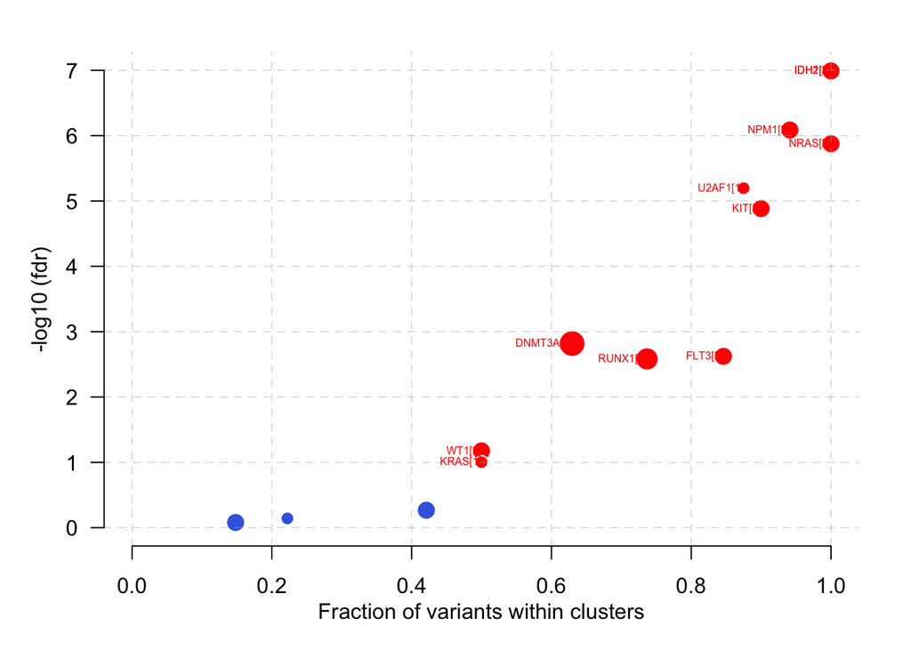

```r
plotOncodrive(res = laml.sig, fdrCutOff = 0.1, useFraction = TRUE, labelSize = 0.5)
```

### adding and summarising pfam domains

amino acid information.

```r
laml.pfam = pfamDomains(maf = laml, AACol = 'Protein_Change', top = 10)
```

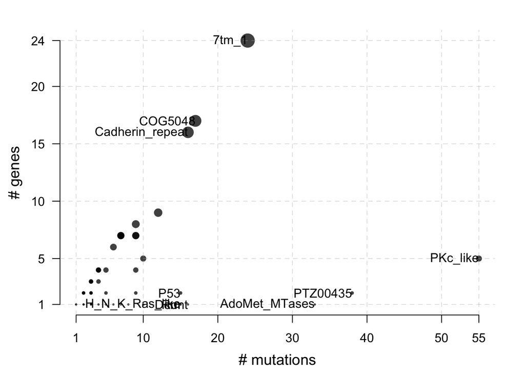

```r
#Protein summary (Printing first 7 columns for display convenience)
laml.pfam$proteinSummary[,1:7, with = FALSE]
```

| HGNC | AAPos | Variant_Classification | N | total | fraction | DomainLabel |
| --- | --- | --- | --- | --- | --- | --- |
| DNMT3A | 882 | Missense_Mutation | 27 | 54 | 0.50000000 | AdoMet_MTases |
| IDH1 | 132 | Missense_Mutation | 18 | 18 | 1.00000000 | PTZ00435 |
| IDH2 | 140 | Missense_Mutation | 17 | 20 | 0.85000000 | PTZ00435 |
| FLT3 | 835 | Missense_Mutation | 14 | 52 | 0.26923077 | PKc_like |
| FLT3 | 599 | In_Frame_Ins | 10 | 52 | 0.19230769 | PKc_like |
| U2AF1 | 34 | Missense_Mutation | 7 | 8 | 0.87500000 | zf-CCCH |
| NRAS | 61 | Missense_Mutation | 6 | 15 | 0.40000000 | H_N_K_Ras_like |
| KIT | 816 | Missense_Mutation | 5 | 10 | 0.50000000 | PTKc_Kit |
| NRAS | 13 | Missense_Mutation | 5 | 15 | 0.33333333 | H_N_K_Ras_like |
| FLT3 | 601 | In_Frame_Ins | 4 | 52 | 0.07692308 | PKc_like |

[output cut: 1506 more lines]

```r
#Domain summary (Printing first 3 columns for display convenience)
laml.pfam$domainSummary[,1:3, with = FALSE]
```

| DomainLabel | nMuts | nGenes |
| --- | --- | --- |
| PKc_like | 55 | 5 |
| PTZ00435 | 38 | 2 |
| AdoMet_MTases | 33 | 1 |
| 7tm_1 | 24 | 24 |
| COG5048 | 17 | 17 |
| Cadherin_repeat | 16 | 16 |
| Runt | 16 | 1 |
| Dcm | 15 | 1 |
| H_N_K_Ras_like | 15 | 1 |
| P53 | 15 | 2 |

[output cut: 493 more lines]

### survival analysis

will estimate probability of survival through the future.

```r
#Survival analysis based on grouping of DNMT3A mutation status
mafSurvival(maf = laml, genes = 'DNMT3A', time = 'days_to_last_followup', Status = 'Overall_Survival_Status', isTCGA = TRUE)
```

```
## Looking for clinical data in annoatation slot of MAF..
```

```
## Number of mutated samples for given genes:
```

```
## DNMT3A
##     48
```

```
## Removed 11 samples with NA's
```

```
## Median survival..
```

```
##     Group medianTime   N
## 1: Mutant        245  45
## 2:     WT        396 137
```

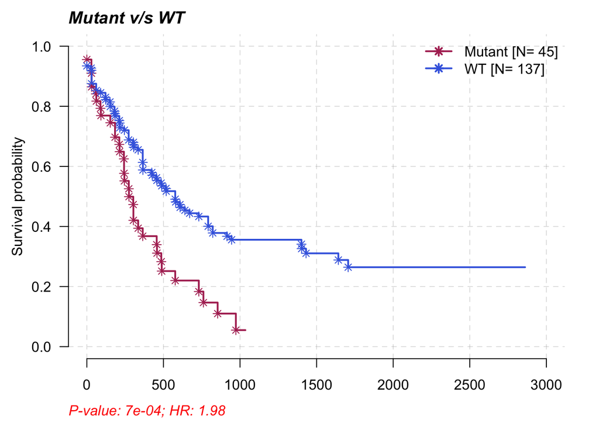

```r
#Using top 20 mutated genes to identify a set of genes (of size 2) to predict poor prognostic groups
prog_geneset = survGroup(maf = laml, top = 20, geneSetSize = 2, time = "days_to_last_followup", Status = "Overall_Survival_Status", verbose = FALSE)
```

```
## Removed 11 samples with NA's
```

```r
print(prog_geneset)
```

```
##     Gene_combination P_value    hr  WT Mutant
##  1:      FLT3_DNMT3A 0.00104 2.510 164     18
##  2:      DNMT3A_SMC3 0.04880 2.220 176      6
##  3:      DNMT3A_NPM1 0.07190 1.720 166     16
##  4:      DNMT3A_TET2 0.19600 1.780 176      6
##  5:        FLT3_TET2 0.20700 1.860 177      5
##  6:        NPM1_IDH1 0.21900 0.495 176      6
##  7:      DNMT3A_IDH1 0.29300 1.500 173      9
##  8:       IDH2_RUNX1 0.31800 1.580 176      6
##  9:        FLT3_NPM1 0.53600 1.210 165     17
## 10:      DNMT3A_IDH2 0.68000 0.747 178      4
## 11:      DNMT3A_NRAS 0.99200 0.986 178      4
```

```r
mafSurvGroup(maf = laml, geneSet = c("DNMT3A", "FLT3"), time = "days_to_last_followup", Status = "Overall_Survival_Status")
```

```
## Looking for clinical data in annoatation slot of MAF..
```

```
## Removed 11 samples with NA's
```

```
## Median survival..
```

```
##     Group medianTime   N
## 1: Mutant      242.5  18
## 2:     WT      379.5 164
```

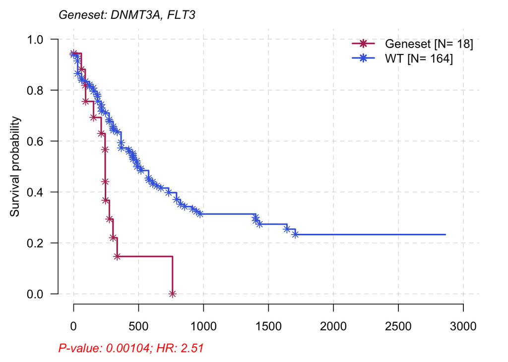

### comparing cohorts (two MAFs)

to understand differentially mutated genes between difference cancer cases or subtypes.

```r
#Primary APL MAF
primary.apl = system.file("extdata", "APL_primary.maf.gz", package = "maftools")
primary.apl = read.maf(maf = primary.apl)
```

```
## -Reading
## -Validating
## --Non MAF specific values in Variant_Classification column:
##   ITD
## -Silent variants: 45
## -Summarizing
## -Processing clinical data
## --Missing clinical data
## -Finished in 0.130s elapsed (0.119s cpu)
```

```r
#Relapse APL MAF
relapse.apl = system.file("extdata", "APL_relapse.maf.gz", package = "maftools")
relapse.apl = read.maf(maf = relapse.apl)
```

```
## -Reading
## -Validating
## --Non MAF specific values in Variant_Classification column:
##   ITD
## -Silent variants: 19
## -Summarizing
## -Processing clinical data
## --Missing clinical data
## -Finished in 0.092s elapsed (0.082s cpu)
```

```r
#Considering only genes which are mutated in at-least in 5 samples in one of the cohort to avoid bias due to genes mutated in single sample.
pt.vs.rt <- mafCompare(m1 = primary.apl, m2 = relapse.apl, m1Name = 'Primary', m2Name = 'Relapse', minMut = 5)
print(pt.vs.rt)
```

```
## $results
##    Hugo_Symbol Primary Relapse         pval         or       ci.up      ci.low
## 1:         PML       1      11 1.529935e-05 0.03537381   0.2552937 0.000806034
## 2:        RARA       0       7 2.574810e-04 0.00000000   0.3006159 0.000000000
## 3:       RUNX1       1       5 1.310500e-02 0.08740567   0.8076265 0.001813280
## 4:        FLT3      26       4 1.812779e-02 3.56086275  14.7701728 1.149009169
## 5:      ARID1B       5       8 2.758396e-02 0.26480490   0.9698686 0.064804160
## 6:         WT1      20      14 2.229087e-01 0.60619329   1.4223101 0.263440988
## 7:        KRAS       6       1 4.334067e-01 2.88486293 135.5393108 0.337679367
## 8:        NRAS      15       4 4.353567e-01 1.85209500   8.0373994 0.553883512
## 9:      ARID1A       7       4 7.457274e-01 0.80869223   3.9297309 0.195710173
##         adjPval
## 1: 0.0001376942
## 2: 0.0011586643
## 3: 0.0393149868
## 4: 0.0407875250
## 5: 0.0496511201
## 6: 0.3343630535
## 7: 0.4897762916
## 8: 0.4897762916
## 9: 0.7457273717
##
## $SampleSummary
##     Cohort SampleSize
## 1: Primary        124
## 2: Relapse         58
```

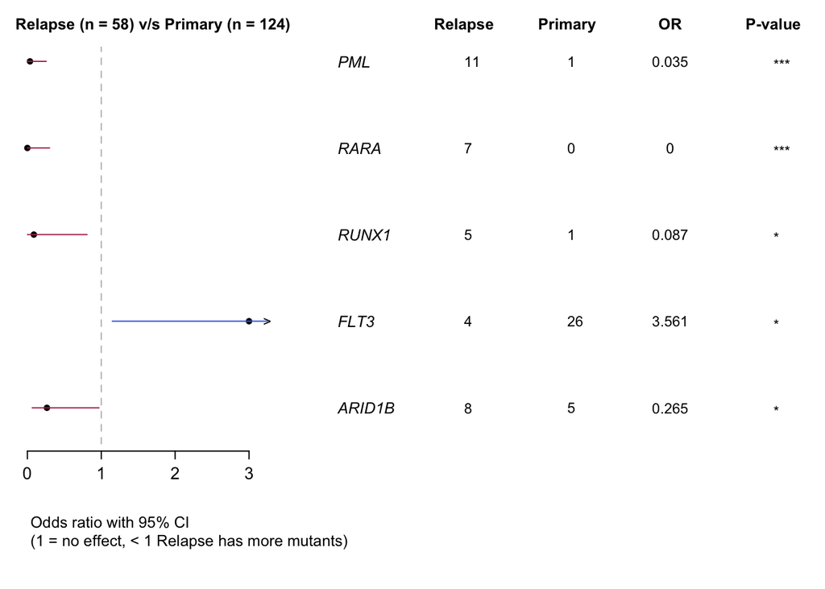

```r
forestPlot(mafCompareRes = pt.vs.rt, pVal = 0.1)
```

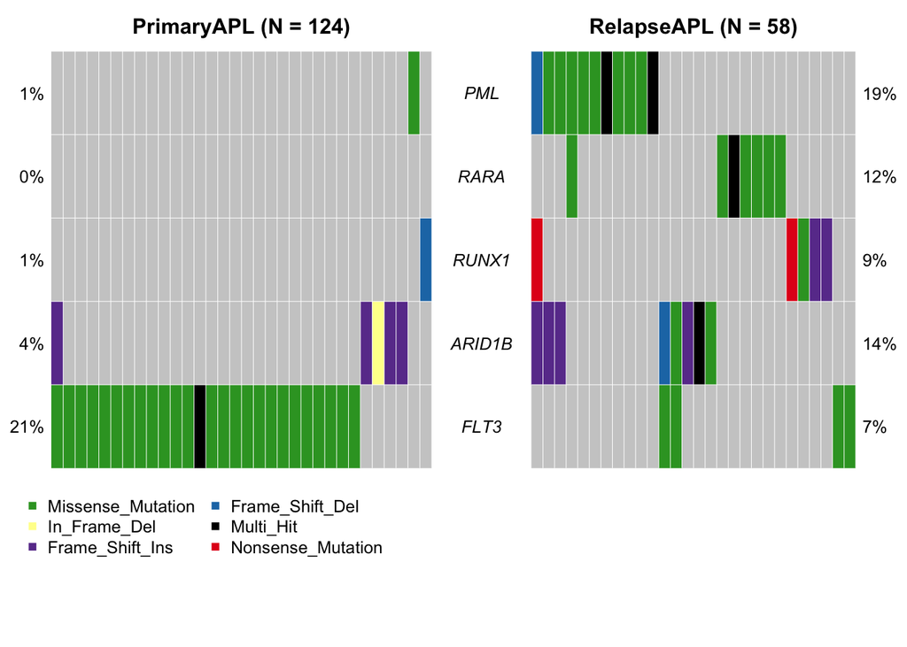

```r
genes = c("PML", "RARA", "RUNX1", "ARID1B", "FLT3")
coOncoplot(m1 = primary.apl, m2 = relapse.apl, m1Name = 'PrimaryAPL', m2Name = 'RelapseAPL', genes = genes, removeNonMutated = TRUE)
```

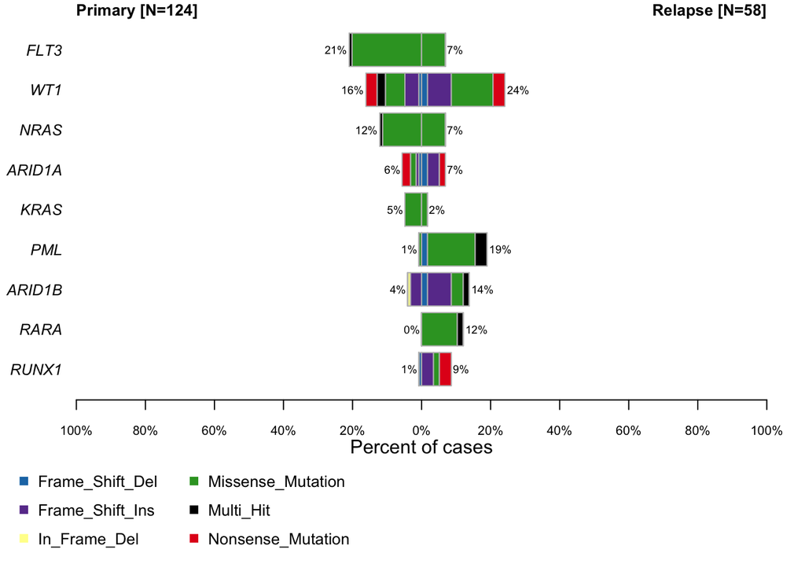

```r
coBarplot(m1 = primary.apl, m2 = relapse.apl, m1Name = "Primary", m2Name = "Relapse")
```

```
## Gene: PML
```

```
## 9 transcripts available. Use arguments refSeqID or proteinID to manually specify tx name.
```

```
##    HGNC refseq.ID protein.ID aa.length
## 1:  PML NM_002675  NP_002666       633
## 2:  PML NM_033238  NP_150241       882
## 3:  PML NM_033239  NP_150242       829
## 4:  PML NM_033240  NP_150243       611
## 5:  PML NM_033244  NP_150247       560
## 6:  PML NM_033246  NP_150249       423
## 7:  PML NM_033247  NP_150250       435
## 8:  PML NM_033249  NP_150252       585
## 9:  PML NM_033250  NP_150253       781
```

```
## Using longer transcript NM_033238 for now.
## 9 transcripts available. Use arguments refSeqID or proteinID to manually specify tx name.
```

```
##    HGNC refseq.ID protein.ID aa.length
## 1:  PML NM_002675  NP_002666       633
## 2:  PML NM_033238  NP_150241       882
## 3:  PML NM_033239  NP_150242       829
## 4:  PML NM_033240  NP_150243       611
## 5:  PML NM_033244  NP_150247       560
## 6:  PML NM_033246  NP_150249       423
## 7:  PML NM_033247  NP_150250       435
## 8:  PML NM_033249  NP_150252       585
## 9:  PML NM_033250  NP_150253       781
```

```
## Using longer transcript NM_033238 for now.
```

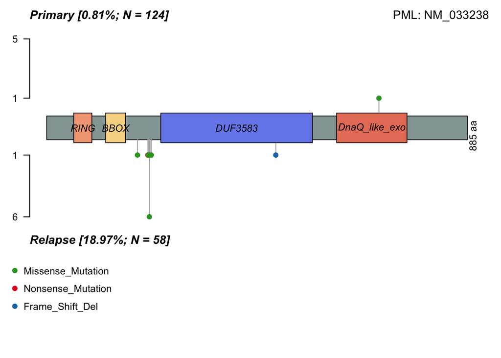

```r
lollipopPlot2(m1 = primary.apl, m2 = relapse.apl, gene = "PML", AACol1 = "amino_acid_change", AACol2 = "amino_acid_change", m1_name = "Primary", m2_name = "Relapse")
```

### Clinical enrichment analysis

enrichment based on clinical features - that is what mutations are most correlated to clinical groupings.

```r
fab.ce = clinicalEnrichment(maf = laml, clinicalFeature = 'FAB_classification')
```

```
## Sample size per factor in FAB_classification:
```

```
##
## M0 M1 M2 M3 M4 M5 M6 M7
## 19 44 44 21 39 19  3  3
```

```r
#Results are returned as a list. Significant associations p-value < 0.05
fab.ce$groupwise_comparision[p_value < 0.05]
```

| Hugo_Symbol | Group1 | Group2 | n_mutated_group1 | n_mutated_group2 | p_value | OR | OR_low | OR_high | fdr |
| --- | --- | --- | --- | --- | --- | --- | --- | --- | --- |
| IDH1 | M1 | Rest | 11 of 44 | 7 of 149 | 0.0002597371 | 6.670592 | 2.173829026 | 21.9607250 | 0.0308575 |
| TP53 | M7 | Rest | 3 of 3 | 12 of 190 | 0.0003857187 | Inf | 5.355415451 | Inf | 0.0308575 |
| DNMT3A | M5 | Rest | 10 of 19 | 38 of 174 | 0.0089427384 | 3.941207 | 1.333635173 | 11.8455979 | 0.3757978 |
| CEBPA | M2 | Rest | 7 of 44 | 6 of 149 | 0.0117352110 | 4.463237 | 1.204699322 | 17.1341278 | 0.3757978 |
| RUNX1 | M0 | Rest | 5 of 19 | 11 of 174 | 0.0117436825 | 5.216902 | 1.243812880 | 19.4051505 | 0.3757978 |
| NPM1 | M5 | Rest | 7 of 19 | 26 of 174 | 0.0248582372 | 3.293201 | 1.001404899 | 10.1210509 | 0.5880102 |
| NPM1 | M3 | Rest | 0 of 21 | 33 of 172 | 0.0278630823 | 0.000000 | 0.000000000 | 0.8651972 | 0.5880102 |
| DNMT3A | M3 | Rest | 1 of 21 | 47 of 172 | 0.0294005111 | 0.133827 | 0.003146708 | 0.8848897 | 0.5880102 |

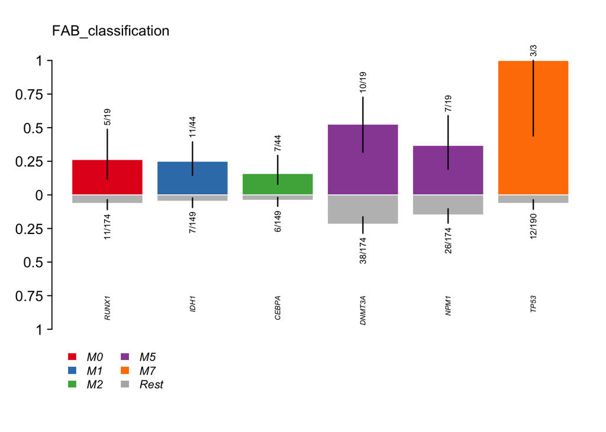

```r
plotEnrichmentResults(enrich_res = fab.ce, pVal = 0.05, geneFontSize = 0.5, annoFontSize = 0.6)
```

### Drug-Gene interactions

checks for drug-gene interactions for druggability check purposes.

```r
dgi = drugInteractions(maf = laml, fontSize = 0.75)
```

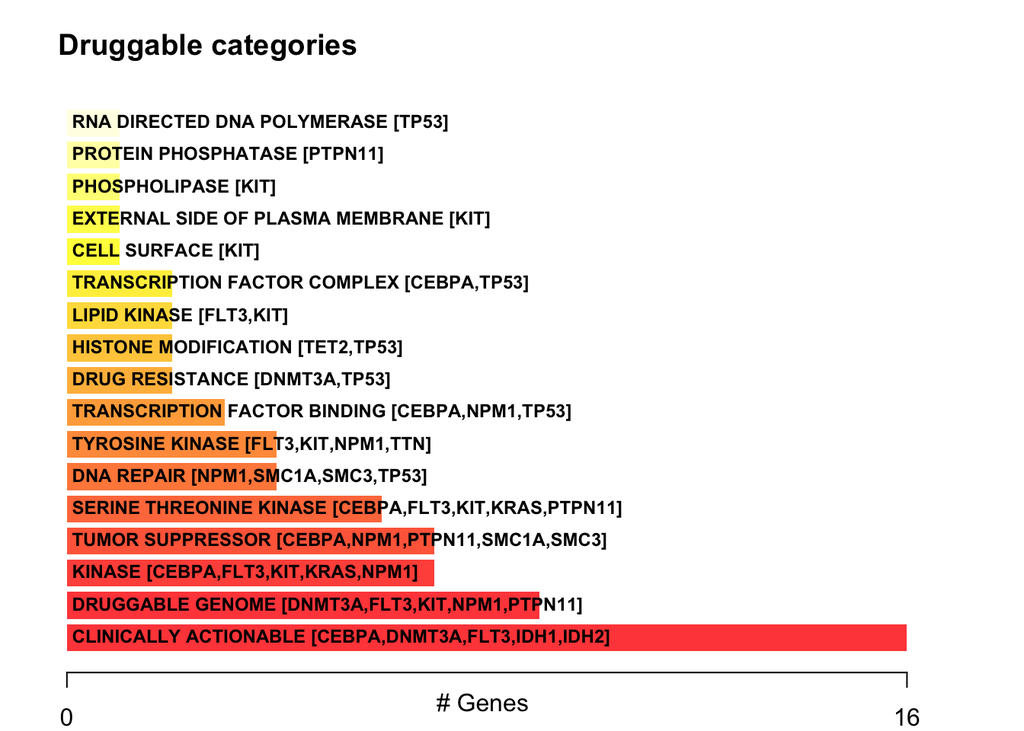

```r
dnmt3a.dgi = drugInteractions(genes = "DNMT3A", drugs = TRUE)
```

```
## Number of claimed drugs for given genes:
##      Gene N
## 1: DNMT3A 7
```

### Oncogenic signaling pathways

checks pathway enrichment based on TCGA cohorts.

```r
# could not run this section
#pws = pathways(maf = laml, plotType = 'treemap')
#plotPathways(maf = laml, pathlist = pws)
```

# References

Mayakonda A, Lin DC, Assenov Y, Plass C, Koeffler HP. 2018. Maftools: efficient and comprehensive analysis of somatic variants in cancer. Genome Resarch. PMID: 30341162